# Week 6 Assignment

Author

Rene Bergeron

## Initialize

Load packages

```r
library(tidytuesdayR)

library(tidyverse)
library(ggside)
library(viridis)
```

Load data from tidytuesday

```r
tuesdata <- tidytuesdayR::tt_load('2025-05-13')
```

```
---- Compiling #TidyTuesday Information for 2025-05-13 ----
--- There is 1 file available ---


── Downloading files ───────────────────────────────────────────────────────────

  1 of 1: "vesuvius.csv"
```

```r
data <- tuesdata$vesuvius
```

## EDA

```r
dataF1 <- data %>% filter(event_id != is.na(event_id) & time != is.na(time) & latitude != is.na(latitude) & longitude != is.na(longitude) & depth_km != is.na(depth_km) & duration_magnitude_md != is.na(duration_magnitude_md) & md_error != is.na(md_error) & area != is.na(area) & type != is.na(type) & review_level != is.na(review_level) & review_level == 'preliminary' & year != is.na(year))
```

This is to see how many observations are complete.

For ease of exploration, I am going to continue with only the complete observations for now.

I may go back and perform final analysis and visualization on original dataset, but for now just complete observations

```r
dataClean <- dataF1 %>% rename(Magnitude = duration_magnitude_md) %>% mutate(year = as_factor(year)) %>% select(time,latitude,longitude,depth_km,Magnitude,year)
```

I left out ‘event ID’ because it is a number that was assigned for data purposes

I left out ‘md_error’ because they are all the same

I left out ‘area’ because they are all the same

I left out ‘type’ because they are all the same

I left out ‘review_level’ because there are only two samples that are different

Hypothesis A: There will be a trend of earthquake magnitudes over time

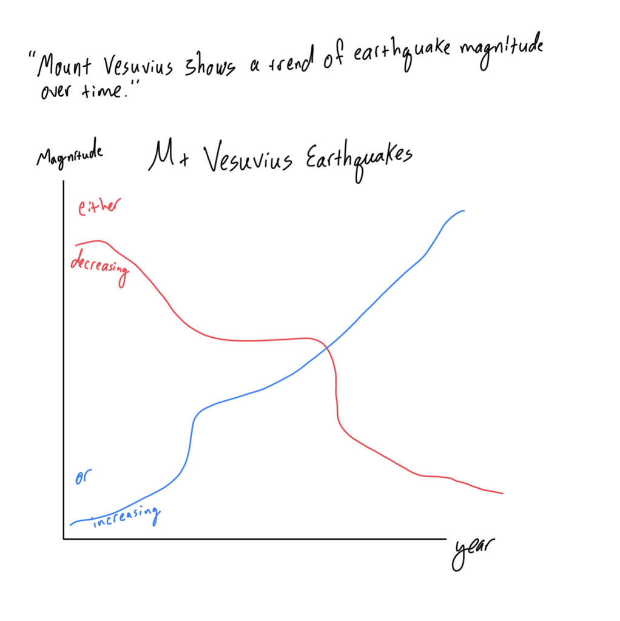

Finding the avg magnitude for each year:

```r
avgByYear <- dataClean %>% group_by(year) %>% summarise(avg_magnitude = mean(Magnitude) , N = n() )
```

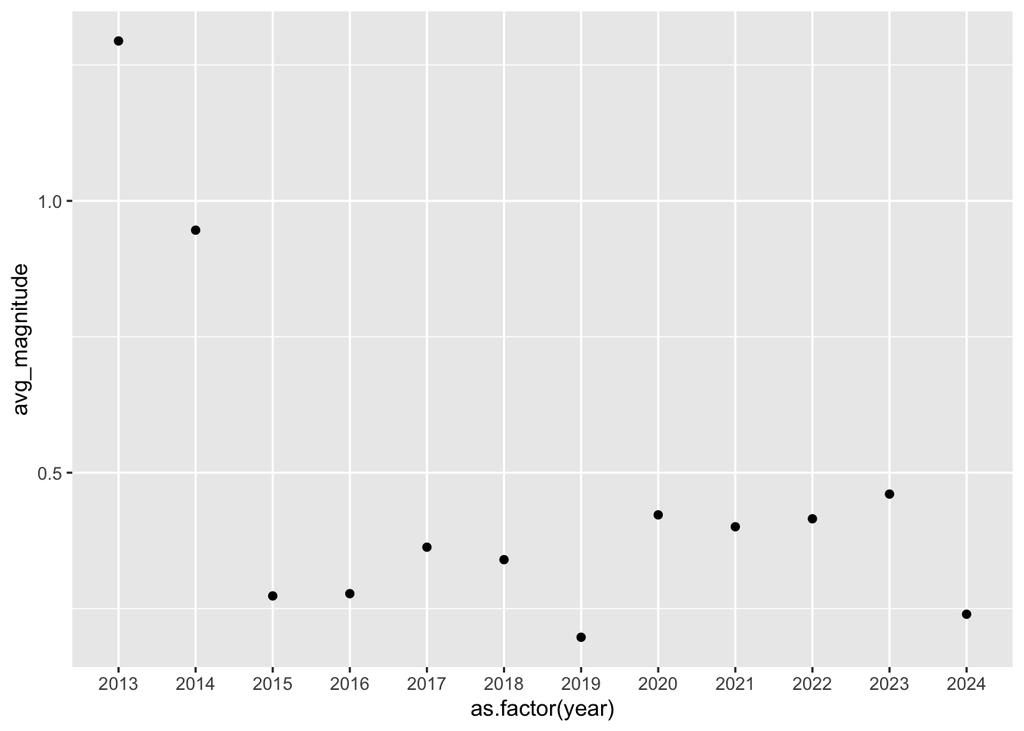

```r
ggplot(avgByYear,aes(as.factor(year),avg_magnitude)) + geom_point()
```

I see no clear trend in the scatterplot

Hypothesis B: Each year will see a different average magnitude

I will need to conduct ANOVA to determine if it is valid to compare these means

I have to first create a dataframe for each year and analyze for ~ normality (I will only be using the years that have a large enough sample size to anlalyze)

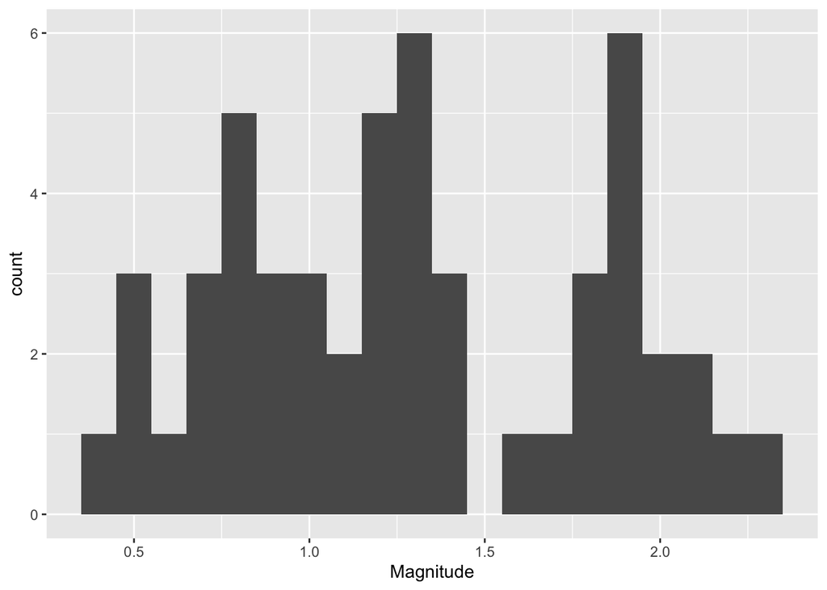

```r
data2013 <- dataClean %>% filter(year== 2013)
ggplot(data2013 , aes(x= Magnitude )) +
  geom_histogram(binwidth = .1)
```

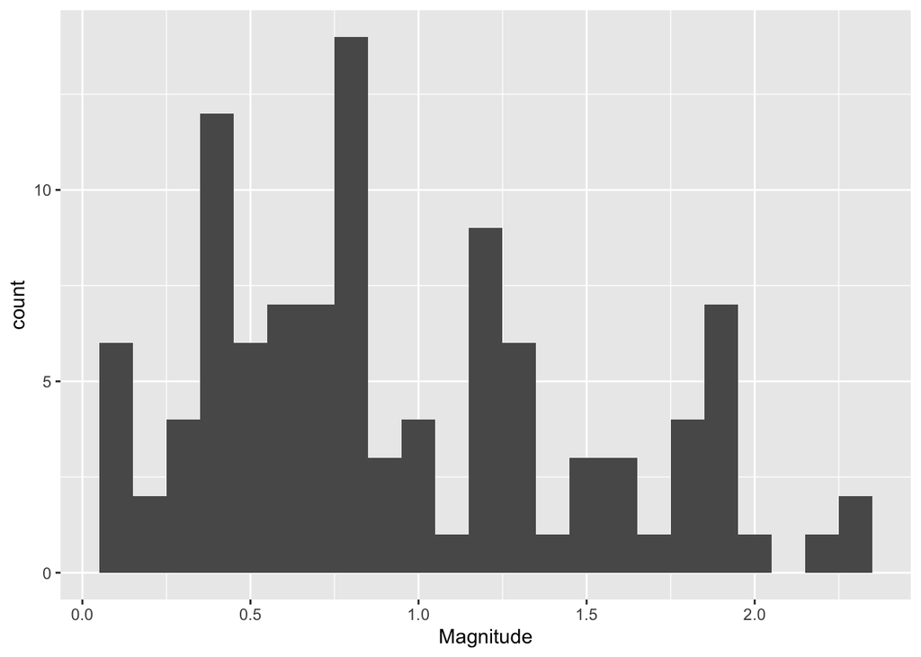

```r
data2014 <- dataClean %>% filter(year== 2014)
ggplot(data2014 , aes(x= Magnitude )) +
  geom_histogram(binwidth = .1)
```

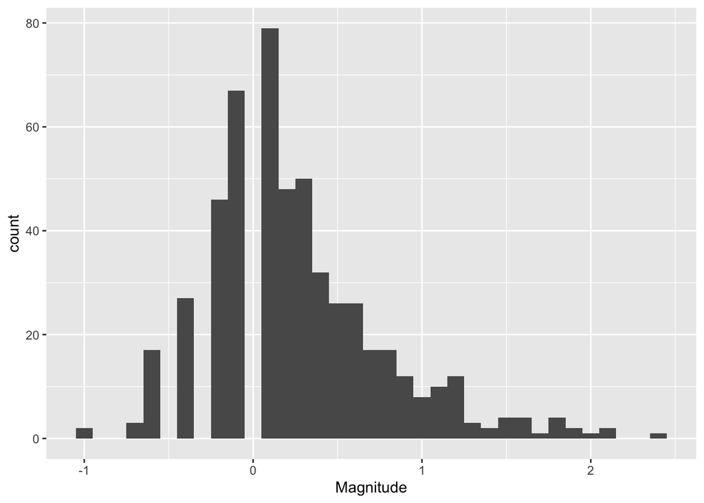

```r
data2015 <- dataClean %>% filter(year== 2015)
ggplot(data2015 , aes(x= Magnitude )) +
  geom_histogram(binwidth = .1)
```

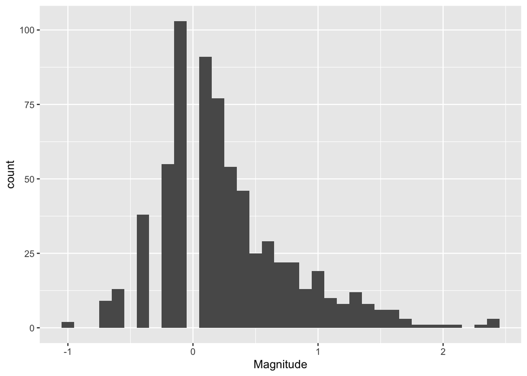

```r
data2016 <- dataClean %>% filter(year== 2016)
ggplot(data2016 , aes(x= Magnitude )) +
  geom_histogram(binwidth = .1)
```

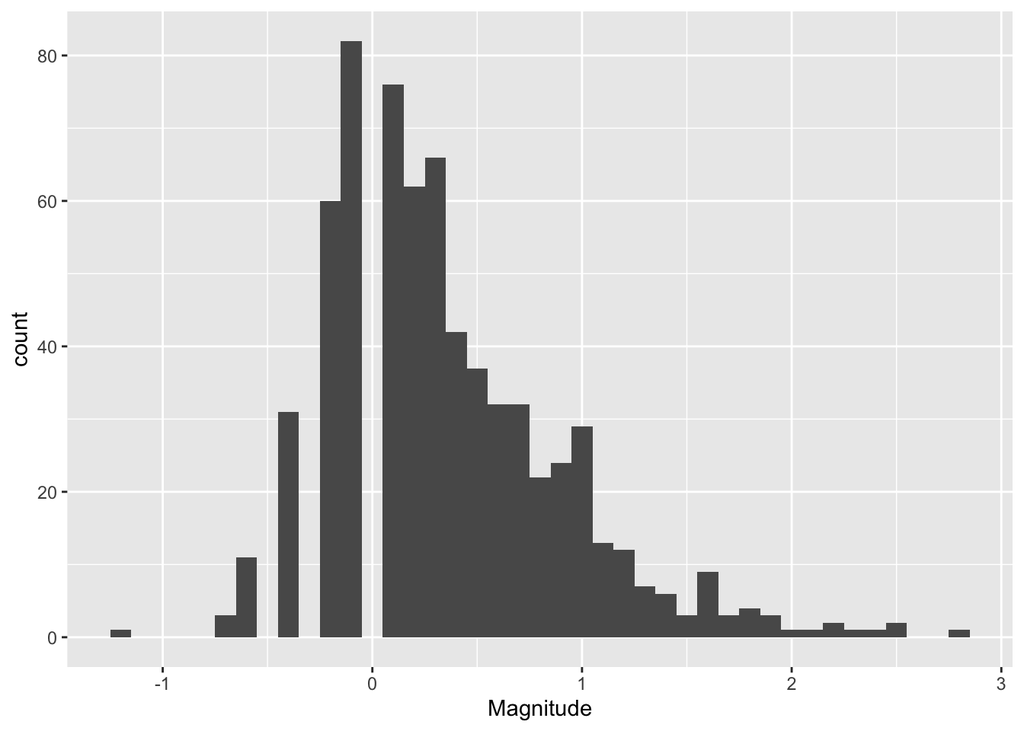

```r
data2017 <- dataClean %>% filter(year== 2017)
ggplot(data2017 , aes(x= Magnitude )) +
  geom_histogram(binwidth = .1)
```

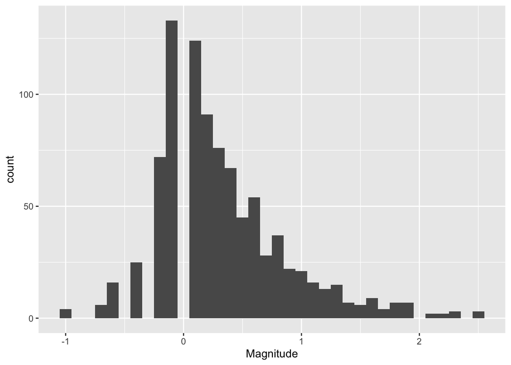

```r
data2018 <- dataClean %>% filter(year== 2018)
ggplot(data2018 , aes(x= Magnitude )) +
  geom_histogram(binwidth = .1)
```

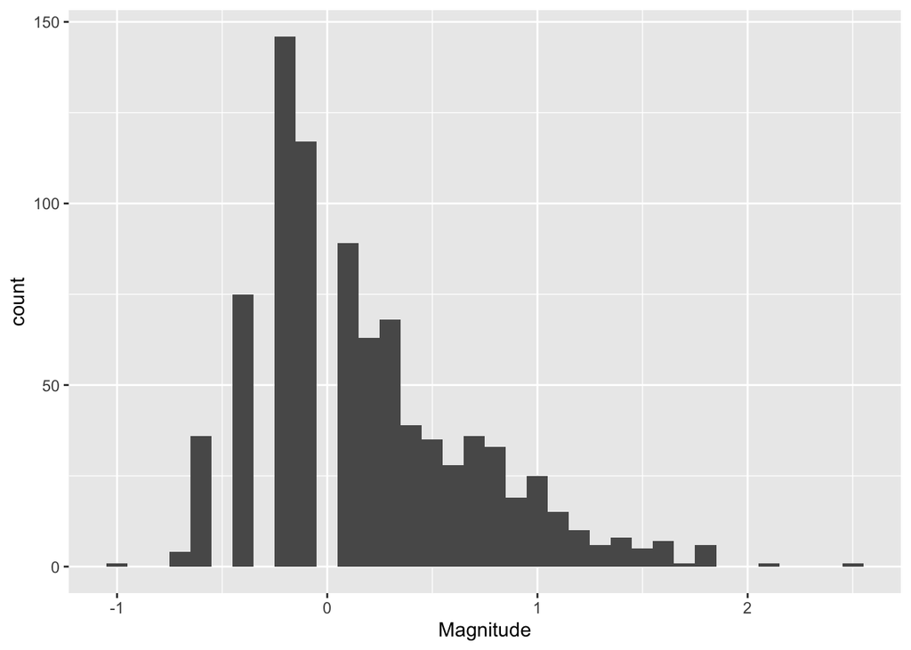

```r
data2019 <- dataClean %>% filter(year== 2019)
ggplot(data2019 , aes(x= Magnitude )) +
  geom_histogram(binwidth = .1)
```

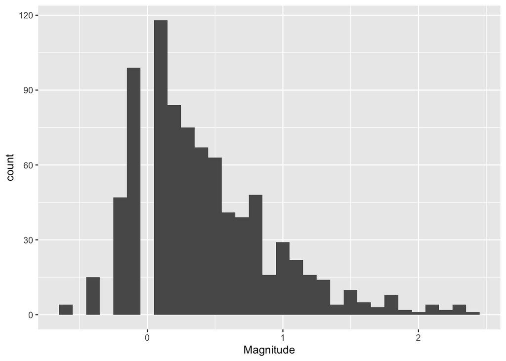

```r
data2020 <- dataClean %>% filter(year== 2020)
ggplot(data2020 , aes(x= Magnitude )) +
  geom_histogram(binwidth = .1)
```

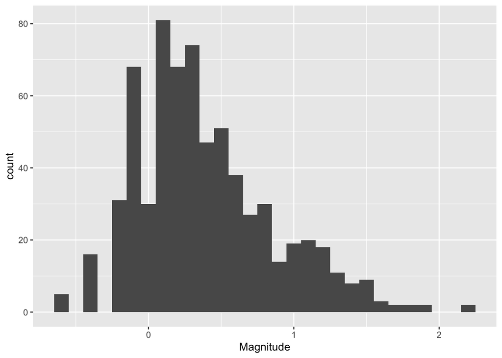

```r
data2021 <- dataClean %>% filter(year== 2021)
ggplot(data2021 , aes(x= Magnitude )) +
  geom_histogram(binwidth = .1)
```

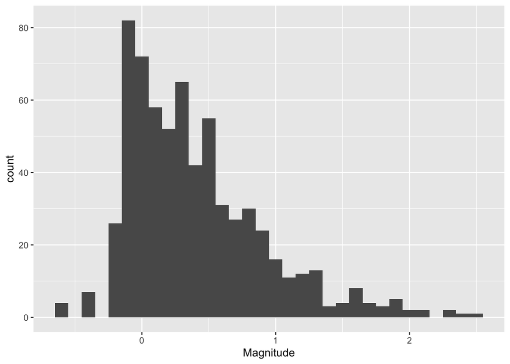

```r
data2022 <- dataClean %>% filter(year== 2022)
ggplot(data2022 , aes(x= Magnitude )) +
  geom_histogram(binwidth = .1)
```

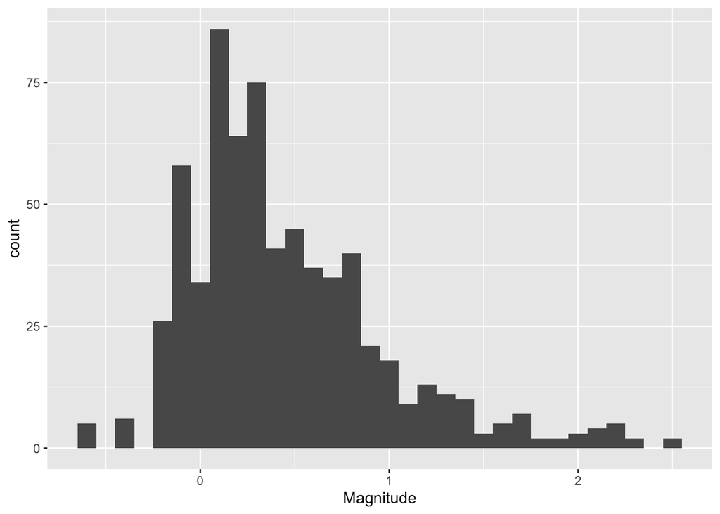

```r
data2023 <- dataClean %>% filter(year== 2023)
ggplot(data2023 , aes(x= Magnitude )) +
  geom_histogram(binwidth = .1)
```

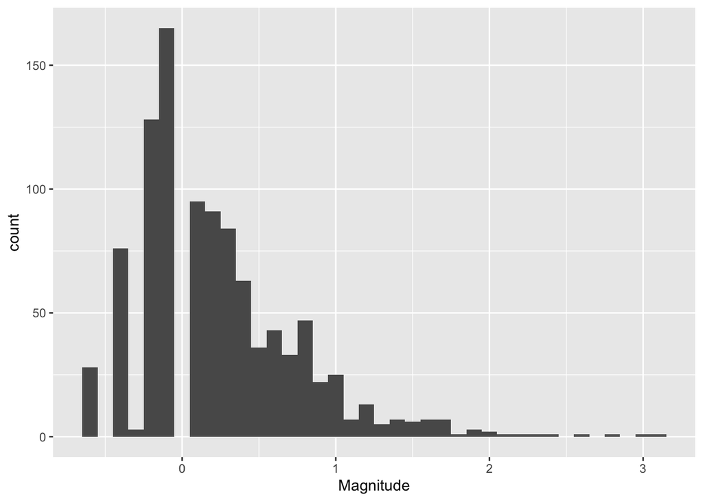

```r
data2024 <- dataClean %>% filter(year== 2024)
ggplot(data2024 , aes(x= Magnitude )) +
  geom_histogram(binwidth = .1)
```

## Back to the ANOVA

```r
anova_model <- aov(Magnitude ~ year, data = dataClean)
summary(anova_model)
```

```
              Df Sum Sq Mean Sq F value Pr(>F)
year          11  139.9  12.718   46.58 <2e-16 ***
Residuals   7667 2093.3   0.273
---
Signif. codes:  0 '***' 0.001 '**' 0.01 '*' 0.05 '.' 0.1 ' ' 1
```

This tells us that at least two of the means are different

```r
TukeyHSD(anova_model)
```

```
  Tukey multiple comparisons of means
    95% family-wise confidence level

Fit: aov(formula = Magnitude ~ year, data = dataClean)

$year
                  diff           lwr          upr     p adj
2014-2013 -0.348076923 -0.6381905134 -0.057963333 0.0050321
2015-2013 -1.020808207 -1.2691818585 -0.772434556 0.0000000
2016-2013 -1.016660813 -1.2624406468 -0.770880980 0.0000000
2017-2013 -0.931196896 -1.1769767293 -0.685417063 0.0000000
2018-2013 -0.954121480 -1.1976361523 -0.710606807 0.0000000
2019-2013 -1.096850907 -1.3406725314 -0.853029282 0.0000000
2020-2013 -0.871757523 -1.1158476289 -0.627667417 0.0000000
2021-2013 -0.893609467 -1.1394280929 -0.647790842 0.0000000
2022-2013 -0.878943760 -1.1249479791 -0.632939541 0.0000000
2023-2013 -0.833513280 -1.0794237492 -0.587602812 0.0000000
2024-2013 -1.054529277 -1.2974569032 -0.811601650 0.0000000
2015-2014 -0.672731284 -0.8561275007 -0.489335067 0.0000000
2016-2014 -0.668583890 -0.8484516976 -0.488716083 0.0000000
2017-2014 -0.583119973 -0.7629877800 -0.403252166 0.0000000
2018-2014 -0.606044557 -0.7828045559 -0.429284557 0.0000000
2019-2014 -0.748773983 -0.9259566190 -0.571591348 0.0000000
2020-2014 -0.523680600 -0.7012325117 -0.346128688 0.0000000
2021-2014 -0.545532544 -0.7254533552 -0.365611734 0.0000000
2022-2014 -0.530866837 -0.7110411342 -0.350692540 0.0000000
2023-2014 -0.485436357 -0.6654826298 -0.305390085 0.0000000
2024-2014 -0.706452354 -0.8824027253 -0.530501982 0.0000000
2016-2015  0.004147394 -0.0952306901  0.103525477 1.0000000
2017-2015  0.089611311 -0.0097667725  0.188989395 0.1246591
2018-2015  0.066686727 -0.0269491247  0.160322580 0.4563384
2019-2015 -0.076042699 -0.1704739537  0.018388555 0.2615120
2020-2015  0.149050684  0.0539283586  0.244173009 0.0000200
2021-2015  0.127198740  0.0277247549  0.226672724 0.0017548
2022-2015  0.141864447  0.0419327063  0.241796188 0.0002216
2023-2015  0.187294927  0.0875941962  0.286995657 0.0000001
2024-2015 -0.033721070 -0.1258194341  0.058377295 0.9893025
2017-2016  0.085463918 -0.0072413105  0.178169146 0.1046590
2018-2016  0.062539334 -0.0239819272  0.149060595 0.4317373
2019-2016 -0.080190093 -0.1675715418  0.007191356 0.1085884
```

[output cut: 18 more lines]

```
2020-2019  0.225093383  0.1425841668  0.307602600 0.0000000
2021-2019  0.203241439  0.1157509386  0.290731940 0.0000000
2022-2019  0.217907146  0.1298965401  0.305917753 0.0000000
2023-2019  0.263337626  0.1755894084  0.351085844 0.0000000
2024-2019  0.042321630 -0.0366823117  0.121325571 0.8440835
2021-2020 -0.021851944 -0.1100878933  0.066384005 0.9996844
2022-2020 -0.007186237 -0.0959379234  0.081565449 1.0000000
2023-2020  0.038244243 -0.0502472525  0.126735738 0.9613205
2024-2020 -0.182771754 -0.2626004313 -0.102943076 0.0000000
2022-2021  0.014665707 -0.0787349280  0.108066343 0.9999968
2023-2021  0.060096187 -0.0330572431  0.153249617 0.6163437
2024-2021 -0.160919809 -0.2458870654 -0.075952553 0.0000000
2023-2022  0.045430480 -0.0482116085  0.139072568 0.9144890
2024-2022 -0.175585517 -0.2610882286 -0.090082804 0.0000000
2024-2023 -0.221015996 -0.3062485995 -0.135783393 0.0000000
```

After some research, this tool does mean testing against all possible pairs of years  
The result was that some years may have similar means, but overall most year pairs are different in mean magnitude.

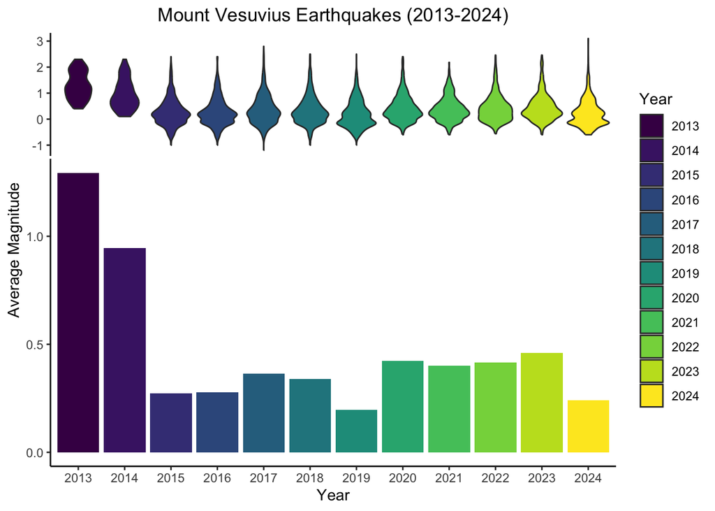

```r
PapaPlot <- ggplot(avgByYear ,
                   aes(x=as.factor(year) ,
                       y=avg_magnitude)) +
  geom_col(aes(fill = as.factor(year))) +
  geom_xsideviolin(data=dataClean,
                   aes(x=year,
                       y=Magnitude,
                       fill = as.factor(year)),
                   orientation = 'x' ) +
  labs(title='Mount Vesuvius Earthquakes (2013-2024)' ,
       y='Average Magnitude' ,
       x='Year' ,
       fill = 'Year') +
  theme_classic() +
  scale_fill_viridis_d() +
  theme(plot.title = element_text(hjust = .5)) +
  theme(ggside.panel.scale.x = .4)

print(PapaPlot)
```